# GGIS 224 - Lab 4

Jonathan Bernard Widjajakusuma, Environmental Data Science @UIUC

12/2/2024

## Overview

In this lab, you’ll explore a few interesting questions about spatial operations based on vector data. You will be on your way to mastering the basics of spatial predicates, topological relations, and spatial subsetting, joining, and aggregation.

Before starting with these questions, you will need to go through *Chapter 4. Spatial Data Operations* in the textbook [Geocomputation in R](https://geocompr.robinlovelace.net/). Feel free to skip Sections 4.2.4 and 4.3 for now. After going through Chapter 4, you will continue using the same data from the spData package to answer the questions below.

It’s a good habit to comment on your codes while you are developing them. This is essential for tracking your own progress, particularly for questions with a complicated logic. The comments are also helpful for improving the readability of the codes. To add a comment, simply type #, followed by your own description. The text after # will be treated as “comments” which will not participate in execution.

Render your completed RmD document by clicking on the “Knit” option in RStudio. Upload the .html file to your lab submission. Your uploaded .html file should follow this naming convention: Lab4_FirstNameInitial_LastName.html (for example, Lab4_E_Hall.html).

## Environment Setup

Load up all libraries needed for this lab.

```r
library(sf)
library(dplyr)
library(spData) #data package needed for this lab
```

Load necessary data sets within the spData package

```r
data("nz_height")
data("nz")
```

## Explore and answer the following questions.

Q1. It was established in Section 4.2 of Chapter 4 that Canterbury was the region of New Zealand containing most of the 100 highest points in the country. How many of these high points does the Canterbury region contain?

```r
#Enter your code chunk that solves the question. Please leave comments as in detail as possible to show your logical development.

#For example, you can start with:
#Subset the boundary of Canterbury from nz, using attribute subsetting.

canterbury = nz |> filter(Name == "Canterbury") #Subset the boundary of Canterbury from nz, using attribute subsetting.
canterbury_height = nz_height[canterbury, ] #Subset the high points from nz_height that are intersected by Canterbury, using spatial subsetting.

#Subset the high points from nz_height that are intersected by Canterbury, using spatial subsetting.
high_points <- nrow(canterbury_height)
high_points
```

```
## [1] 70
```

How many of these high points does the Canterbury region contain?

*70*

Q2. Plot the result of Q1 using the plot() function to create a map showing (1) all of New Zealand, (2) the Canterbury region highlighted (filled) in yellow, (3) high points in Canterbury represented by red X’s (hint: pch = 4) and (4) high points in other parts of New Zealand represented by blue circles. See the help page ?points for details with an illustration of different pch values.

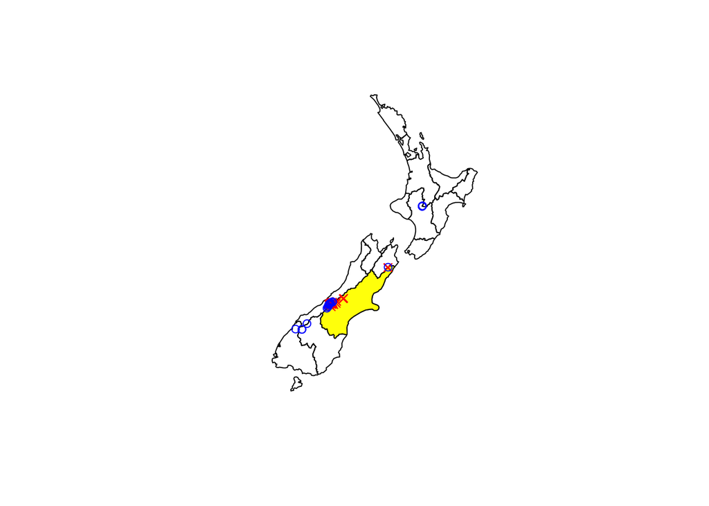

```r
#Enter your code chunk that creates the plot.
plot(st_geometry(nz))
plot(st_geometry(canterbury), col = "yellow", add = TRUE)

# Plot high points in Canterbury in red X (if any)
if (nrow(canterbury_height) > 0) {
  coords_canterbury_height <- st_coordinates(canterbury_height)
  points(coords_canterbury_height, col = "red", pch = 4)
}

# Plot high points in other parts of New Zealand in blue circle (if any)
other_heights <- nz_height[canterbury, , op=st_disjoint]
if (nrow(other_heights) > 0) {
  coords_other_height <- st_coordinates(other_heights)
  points(coords_other_height, col = "blue", pch = 1)
}
```

Q3. Which region has the second highest number of nz_height points, and how many does it have? Hint: consider using the function n() within [summarize()](https://dplyr.tidyverse.org/reference/summarise.html).

BONUS (+1 pt): What is the average elevation of the high points within this region (which has the second highest number of high points)?

```r
#Enter your code chunk that answers the question.
nz_height_region <- st_join(nz_height, nz)

# Aggregate the high points count per region and calculate the average elevation
aggregate_data <- nz_height_region %>%
  group_by(Name) %>%
  summarize(Count = n(), Average_Elevation = mean(elevation))

# Find the region with the second highest number of high points
aggregate_data <- aggregate_data[order(-aggregate_data$Count),]
second_highest <- aggregate_data[2, ]
second_highest
```

```
## Simple feature collection with 1 feature and 3 fields
## Geometry type: MULTIPOINT
## Dimension:     XY
## Bounding box:  xmin: 1259702 ymin: 5076570 xmax: 1384195 ymax: 5183108
## Projected CRS: NZGD2000 / New Zealand Transverse Mercator 2000
## # A tibble: 1 × 4
##   Name       Count Average_Elevation                                    geometry
##   <chr>      <int>             <dbl>                            <MULTIPOINT [m]>
## 1 West Coast    22             2889. ((1259702 5076570), (1357203 5151999), (13…
```

What is the region and how many does it have?

*The West Coast, with 22 high points*

What is the average elevation of the high points within this region (Extra Credit +1 pt)?

*2889.455*

Q4. Test your knowledge of spatial predicates by finding out and plotting how US states relate to each other. You’ll be using the us_states layer in the spData package as you did for Lab 3.

1. Create an sf object representing the state of Colorado (hint: Colorado = us_states[us_states$NAME == “Colorado”,], or use filter), and then (2) plot all of the United States and (3) add Colorado filled in blue.

Next, (4) create a new object representing all the states that are geographically contiguous(hint: st_touches) with Colorado, and (5) plot them with a yellow filling on the same map.

Then, (6) create another object representing all the states that are within a distance of 200 miles from Colorado, and (7) plot them with a red outline (hollow filling) on the same map.

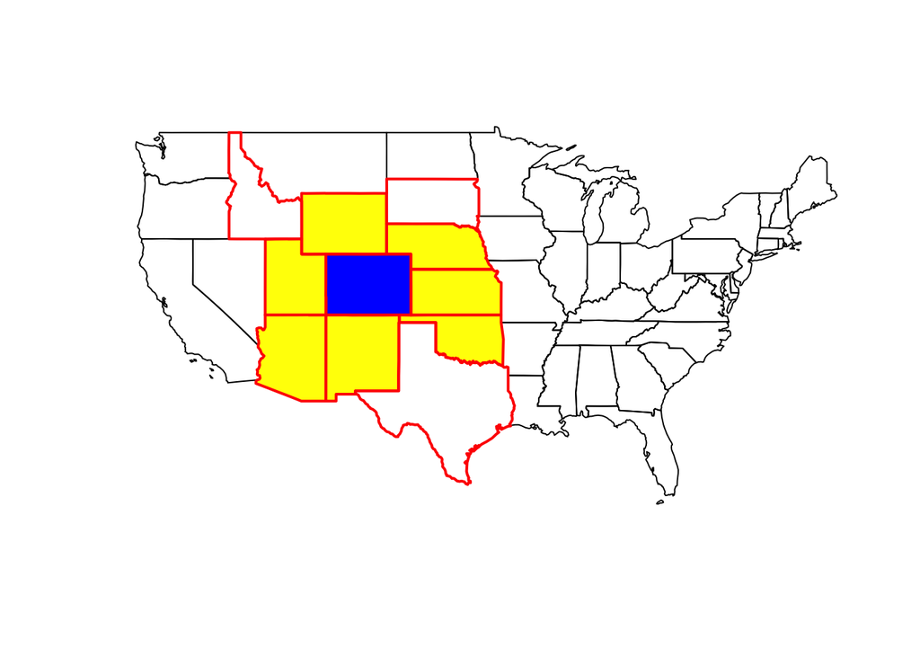

```r
data(us_states)

#Enter your code to generate the map.
colorado <- us_states[us_states$NAME == "Colorado", ]

# plotting all us states
plot(st_geometry(us_states))

# plot colarado in blue
plot(st_geometry(colorado), col = "blue", add = TRUE)

# find the contigous states, and plot it in yellow
contiguos_states_indices <- st_touches(colorado, us_states)[[1]]
contigous_states <- us_states[contiguos_states_indices, ]
plot(st_geometry(contigous_states), col = "yellow", add = TRUE)

# find states within 200 miles of colarado and plot with red outline
states_within_200_indices <- st_is_within_distance(colorado, us_states, dist = 200*1609.34)
near_states <- us_states[unlist(states_within_200_indices), ]
plot(st_geometry(near_states), border = "red", add = TRUE, lwd = 2)
```

Q5. When you are subsetting the states that are geographically contiguous with Colorado (part of Q4), you can use either st_touches or st_intersects predicates. Experiment the results using both predicates (no need to submit code here) (1 pt).

What difference did you notice? And based on your experiment, can you briefly summarize the difference between st_touches and st_intersects?

*The main difference between st_touches and st_intersects is the different types of spatial relationships they identify. st_touches is able to detecet geometries that have the same boundary but does not overlaps. On the other hand, st_intersects have a range of interactions such as overlapping, touching and containment. Therefore it has many different uses.*

Render your document by clicking on the “Knit” option in RStudio. Upload the .html file to your assignment submission!

.